# Machine Learning Assignment 2

# 6. (3pt) Use appropriate plots and statistic tests to find which variables in the dataset are associated with “income”. Remove the variable(s) that are not associated with income.

The numerical variables are: 1. age - numeric 2. fnlwt which is final weight - continuous 3. Education-num - numeric 4. Capital-gain - continuous 5. capital-loss - continuous 6. hours-per-week - numeric

The categorical variables are: 1. workclass 2. marital-status 3. occupation 4. relationship 5. race 6. sex - binary type 7. native-country

```r
adult
```

| age | workclass | fnlwgt | education | education_num | marital_status | occupation | relationship | race | sex | capital_gain | capital_loss | hours_per_week | native_country | income |
| --- | --- | --- | --- | --- | --- | --- | --- | --- | --- | --- | --- | --- | --- | --- |
| 39 | State-gov | 77516 | Bachelors | 13 | Never-married | Adm-clerical | Not-in-family | White | Male | 2174 | 0 | 40 | United-States | <=50K |
| 50 | Self-emp-not-inc | 83311 | Bachelors | 13 | Married-civ-spouse | Exec-managerial | Husband | White | Male | 0 | 0 | 13 | United-States | <=50K |
| 38 | Private | 215646 | HS-grad | 9 | Divorced | Handlers-cleaners | Not-in-family | White | Male | 0 | 0 | 40 | United-States | <=50K |
| 53 | Private | 234721 | 11th | 7 | Married-civ-spouse | Handlers-cleaners | Husband | Black | Male | 0 | 0 | 40 | United-States | <=50K |
| 28 | Private | 338409 | Bachelors | 13 | Married-civ-spouse | Prof-specialty | Wife | Black | Female | 0 | 0 | 40 | Other | <=50K |
| 37 | Private | 284582 | Masters | 14 | Married-civ-spouse | Exec-managerial | Wife | White | Female | 0 | 0 | 40 | United-States | <=50K |
| 49 | Private | 160187 | 9th | 5 | Married-spouse-absent | Other-service | Not-in-family | Black | Female | 0 | 0 | 16 | Other | <=50K |
| 52 | Self-emp-not-inc | 209642 | HS-grad | 9 | Married-civ-spouse | Exec-managerial | Husband | White | Male | 0 | 0 | 45 | United-States | >50K |
| 31 | Private | 45781 | Masters | 14 | Never-married | Prof-specialty | Not-in-family | White | Female | 14084 | 0 | 50 | United-States | >50K |
| 42 | Private | 159449 | Bachelors | 13 | Married-civ-spouse | Exec-managerial | Husband | White | Male | 5178 | 0 | 40 | United-States | >50K |

[output cut: 990 more lines]

```
    Pearson's Chi-squared test

data:  table(adult[[var]], adult$income)
X-squared = 1045.7, df = 8, p-value < 2.2e-16
```

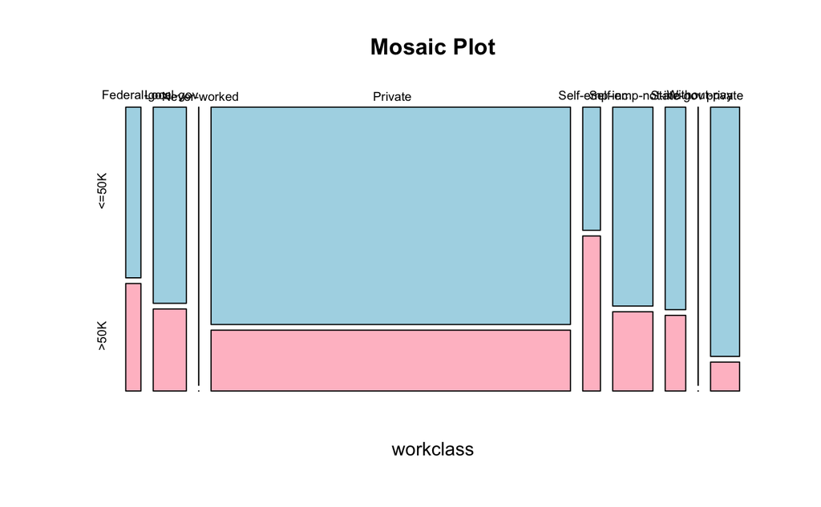

```
    Pearson's Chi-squared test

data:  table(adult[[var]], adult$income)
X-squared = 6517.7, df = 6, p-value < 2.2e-16
```

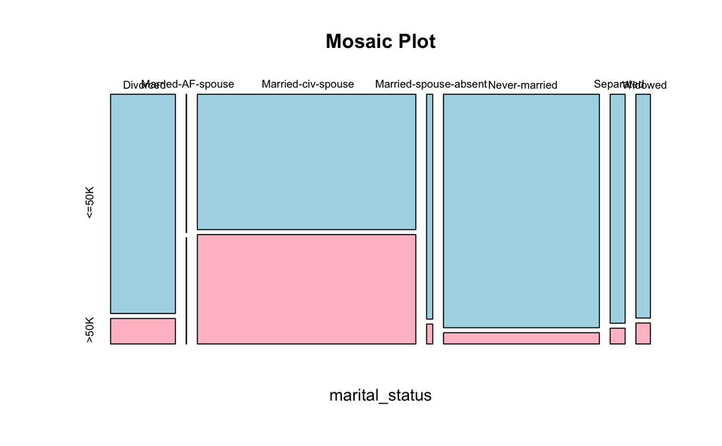

```
    Pearson's Chi-squared test

data:  table(adult[[var]], adult$income)
X-squared = 4032, df = 14, p-value < 2.2e-16
```

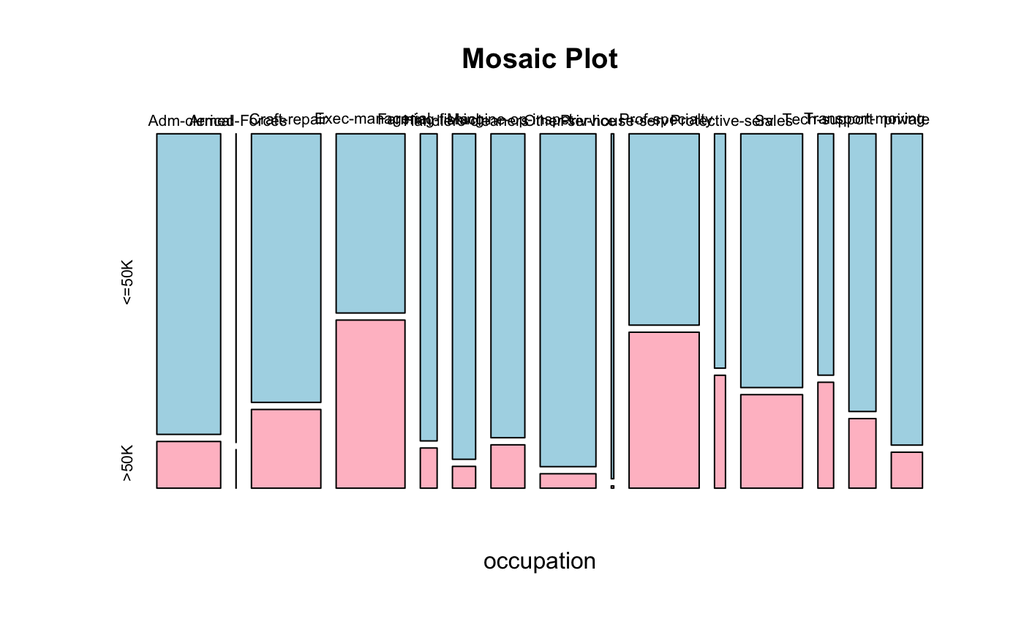

```
    Pearson's Chi-squared test

data:  table(adult[[var]], adult$income)
X-squared = 6699.1, df = 5, p-value < 2.2e-16
```

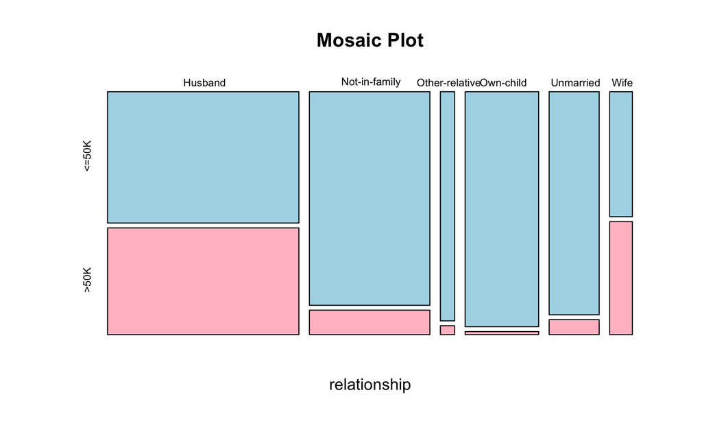

```
    Pearson's Chi-squared test

data:  table(adult[[var]], adult$income)
X-squared = 330.92, df = 4, p-value < 2.2e-16
```

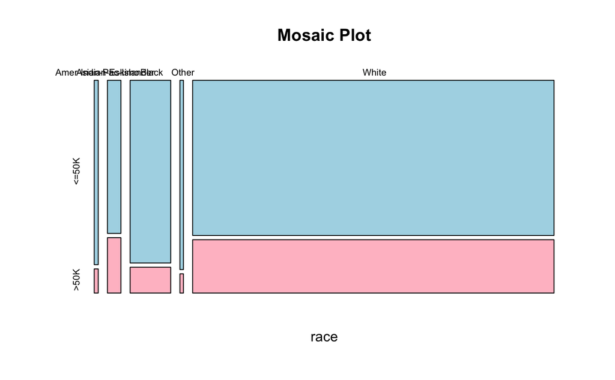

```
    Pearson's Chi-squared test with Yates' continuity correction

data:  table(adult[[var]], adult$income)
X-squared = 1517.8, df = 1, p-value < 2.2e-16
```

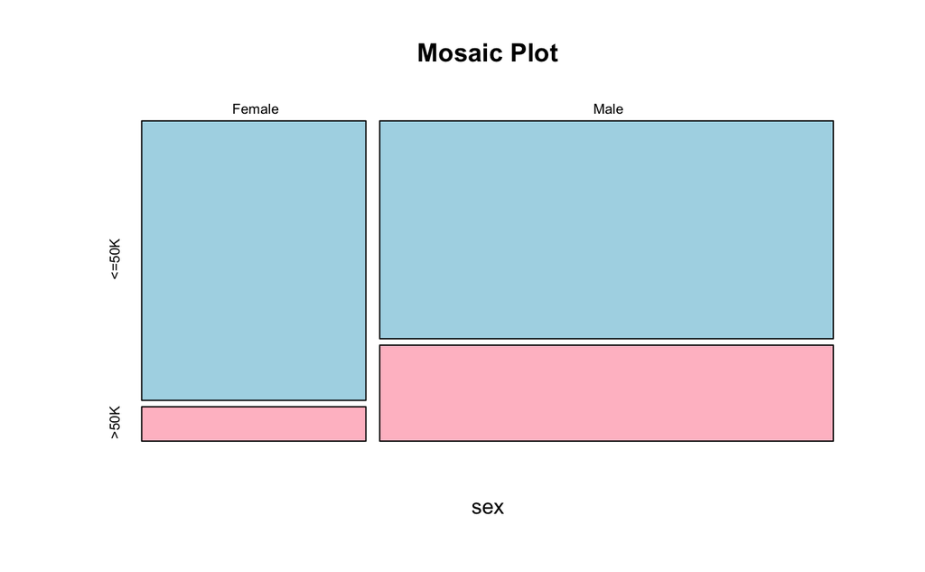

```
    Pearson's Chi-squared test with Yates' continuity correction

data:  table(adult[[var]], adult$income)
X-squared = 38.426, df = 1, p-value = 5.688e-10
```

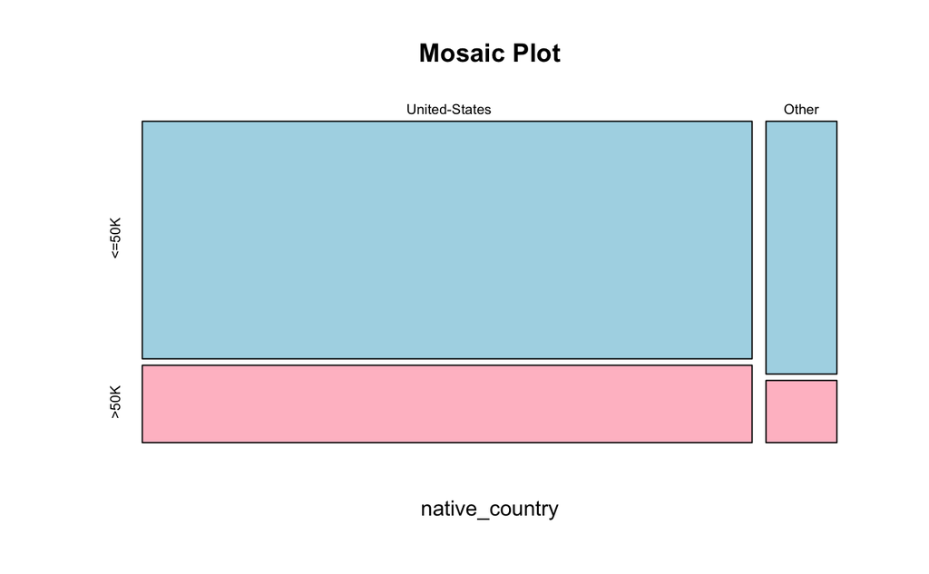

```r
# Using Chi-Square Test as both are categorical variables
categorical_vars <- c("workclass", "marital_status", "occupation","relationship", "race", "sex", "native_country")

for (var in categorical_vars) {
  # Perform chi-squared test
  adult_chisq <- chisq.test(table(adult[[var]], adult$income))
  mosaicplot(table(adult[[var]], adult$income), main = "Mosaic Plot", color = c("lightblue", "pink"),ylab(var))
  print(adult_chisq)
}
```

All the p-values are less than 0.01, therefore, we can conclude that they are all extremely associated.

```r
# Using t-test for numerical
adult_t_test <- t.test(age ~ income, data = adult)
print(adult_t_test)
```

```
    Welch Two Sample t-test

data:  age by income
t = -50.264, df = 17411, p-value < 2.2e-16
alternative hypothesis: true difference in means between group  <=50K and group  >50K is not equal to 0
95 percent confidence interval:
 -7.757250 -7.174955
sample estimates:
mean in group  <=50K  mean in group  >50K
            36.78374             44.24984
```

```r
adult_t_test <- t.test(fnlwgt ~ income, data = adult)
print(adult_t_test)
```

```
    Welch Two Sample t-test

data:  fnlwgt by income
t = 1.7412, df = 13615, p-value = 0.08167
alternative hypothesis: true difference in means between group  <=50K and group  >50K is not equal to 0
95 percent confidence interval:
 -293.7029 4965.4332
sample estimates:
mean in group  <=50K  mean in group  >50K
            190340.9             188005.0
```

```r
adult_t_test <- t.test(`hours_per_week` ~ income, data = adult)
print(adult_t_test)
```

```
    Welch Two Sample t-test

data:  hours_per_week by income
t = -45.123, df = 14570, p-value < 2.2e-16
alternative hypothesis: true difference in means between group  <=50K and group  >50K is not equal to 0
95 percent confidence interval:
 -6.920943 -6.344690
sample estimates:
mean in group  <=50K  mean in group  >50K
            38.84021             45.47303
```

```r
adult_t_test <- t.test(`education_num` ~ income, data = adult)
print(adult_t_test)
```

```
    Welch Two Sample t-test

data:  education_num by income
t = -64.896, df = 13421, p-value < 2.2e-16
alternative hypothesis: true difference in means between group  <=50K and group  >50K is not equal to 0
95 percent confidence interval:
 -2.077502 -1.955682
sample estimates:
mean in group  <=50K  mean in group  >50K
            9.595065            11.611657
```

```r
adult_t_test <- t.test(`capital_gain` ~ income, data = adult)
print(adult_t_test)
```

```
    Welch Two Sample t-test

data:  capital_gain by income
t = -23.427, df = 7861.7, p-value < 2.2e-16
alternative hypothesis: true difference in means between group  <=50K and group  >50K is not equal to 0
95 percent confidence interval:
 -4180.166 -3534.614
sample estimates:
mean in group  <=50K  mean in group  >50K
            148.7525            4006.1425
```

```r
adult_t_test <- t.test(`capital_loss` ~ income, data = adult)
print(adult_t_test)
```

```
    Welch Two Sample t-test

data:  capital_loss by income
t = -20.238, df = 9231.1, p-value < 2.2e-16
alternative hypothesis: true difference in means between group  <=50K and group  >50K is not equal to 0
95 percent confidence interval:
 -155.5985 -128.1187
sample estimates:
mean in group  <=50K  mean in group  >50K
            53.14292            195.00153
```

```r
adult_t_test <- t.test(`hours_per_week` ~ income, data = adult)
print(adult_t_test)
```

```
    Welch Two Sample t-test

data:  hours_per_week by income
t = -45.123, df = 14570, p-value < 2.2e-16
alternative hypothesis: true difference in means between group  <=50K and group  >50K is not equal to 0
95 percent confidence interval:
 -6.920943 -6.344690
sample estimates:
mean in group  <=50K  mean in group  >50K
            38.84021             45.47303
```

We’ll remove this feature - fnlwgt as the p-value is greater than the threshhold value ie. 0.05

```r
adult <- adult[, !names(adult) %in% c("fnlwgt")]
adult
```

| age | workclass | education | education_num | marital_status | occupation | relationship | race | sex | capital_gain | capital_loss | hours_per_week | native_country | income |
| --- | --- | --- | --- | --- | --- | --- | --- | --- | --- | --- | --- | --- | --- |
| 39 | State-gov | Bachelors | 13 | Never-married | Adm-clerical | Not-in-family | White | Male | 2174 | 0 | 40 | United-States | <=50K |
| 50 | Self-emp-not-inc | Bachelors | 13 | Married-civ-spouse | Exec-managerial | Husband | White | Male | 0 | 0 | 13 | United-States | <=50K |
| 38 | Private | HS-grad | 9 | Divorced | Handlers-cleaners | Not-in-family | White | Male | 0 | 0 | 40 | United-States | <=50K |
| 53 | Private | 11th | 7 | Married-civ-spouse | Handlers-cleaners | Husband | Black | Male | 0 | 0 | 40 | United-States | <=50K |
| 28 | Private | Bachelors | 13 | Married-civ-spouse | Prof-specialty | Wife | Black | Female | 0 | 0 | 40 | Other | <=50K |
| 37 | Private | Masters | 14 | Married-civ-spouse | Exec-managerial | Wife | White | Female | 0 | 0 | 40 | United-States | <=50K |
| 49 | Private | 9th | 5 | Married-spouse-absent | Other-service | Not-in-family | Black | Female | 0 | 0 | 16 | Other | <=50K |
| 52 | Self-emp-not-inc | HS-grad | 9 | Married-civ-spouse | Exec-managerial | Husband | White | Male | 0 | 0 | 45 | United-States | >50K |
| 31 | Private | Masters | 14 | Never-married | Prof-specialty | Not-in-family | White | Female | 14084 | 0 | 50 | United-States | >50K |
| 42 | Private | Bachelors | 13 | Married-civ-spouse | Exec-managerial | Husband | White | Male | 5178 | 0 | 40 | United-States | >50K |

[output cut: 990 more lines]

Let’s create some boxplots

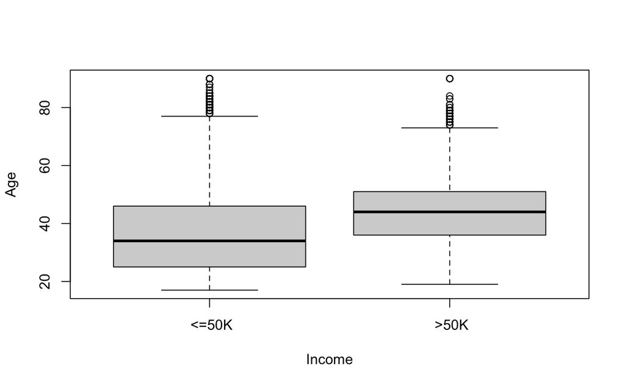

```r
# Create a boxplot of the 'age' variable grouped by 'income' categories
boxplot(age ~ income, data = adult, xlab = "Income", ylab = "Age")
```

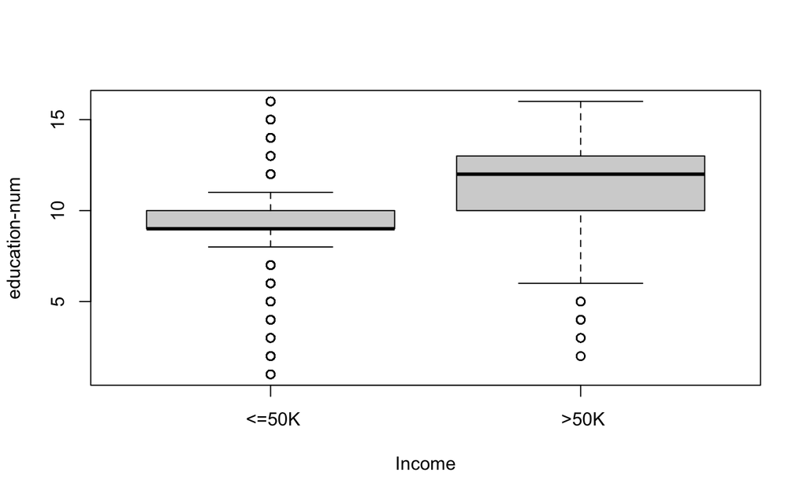

```r
boxplot(education_num ~ income, data = adult, xlab = "Income", ylab = "education-num")
```

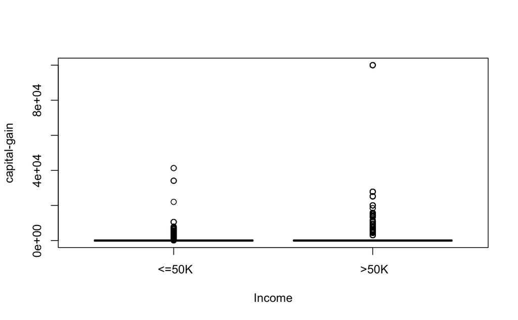

```r
boxplot(capital_gain ~ income, data = adult, xlab = "Income", ylab = "capital-gain")
```

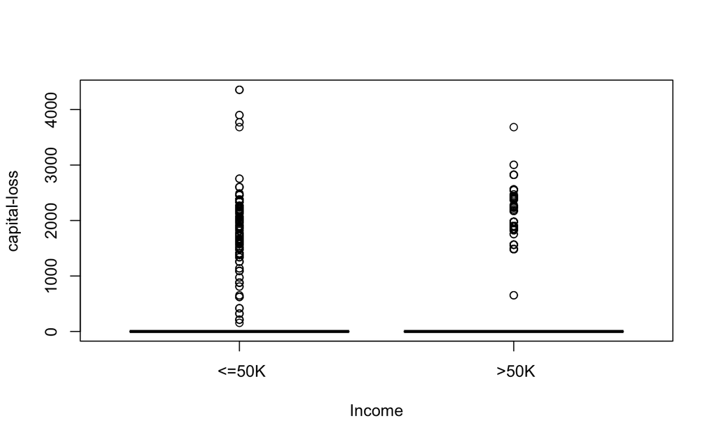

```r
boxplot(capital_loss ~ income, data = adult, xlab = "Income", ylab = "capital-loss")
```

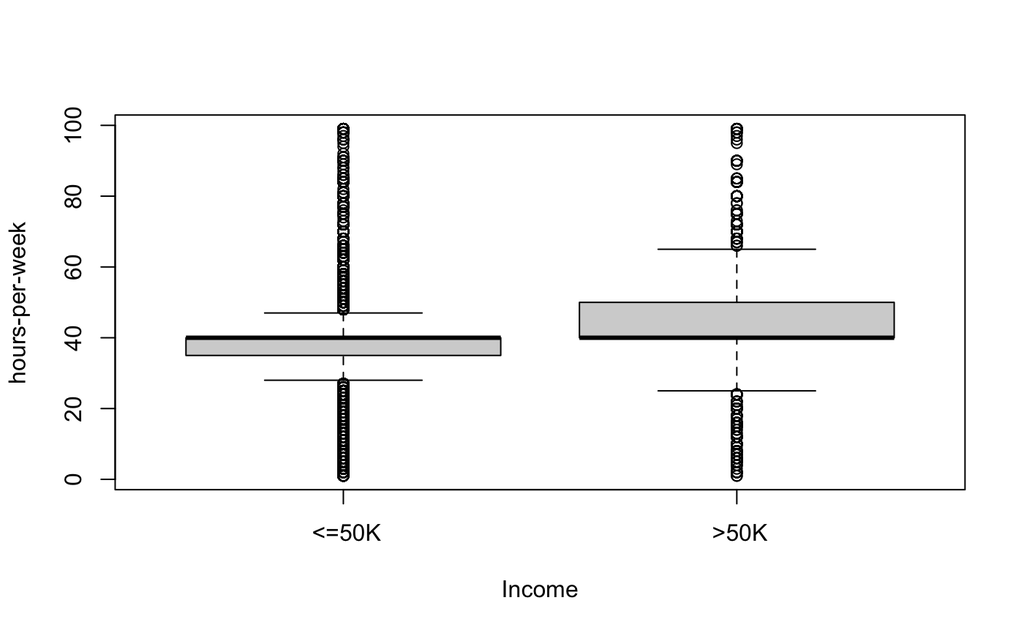

```r
boxplot(hours_per_week ~ income, data = adult, xlab = "Income", ylab = "hours-per-week")
```

```r
# Splitting the data into train and test sets
train_indices <- sample(1:nrow(adult), 0.8 * nrow(adult))  # 80% for training

# Split the data into training and testing sets
train_adult_set <- adult[train_indices, ]
test_adult_set <- adult[-train_indices, ]
```

# 7. (2pt) Train a logistic regression model on the train data (preprocessed and transformed using above steps) using the glm package and use it to predict “income” for the test data. Note: As explained in the lectures, “predict” method will return predicted probabilities. To convert them to labels, you need to use some threshold ( typically set as 50%) and if the predicted probability is greater than 50% you predict income>50K; otherwise predict income<=50K ( please review the example in lecture 7.2).

The categorical variables are: 1. workclass 2. marital-status 3. occupation 4. relationship 5. race 6. sex - binary type 7. native-country

```r
library(data.table)
library(mltools)
# Factorize categorical variables for train data
train_adult_set$workclass <- as.factor(train_adult_set$workclass)
train_adult_set$marital_status <- as.factor(train_adult_set$marital_status)
train_adult_set$occupation <- as.factor(train_adult_set$occupation)
train_adult_set$relationship <- as.factor(train_adult_set$relationship)
train_adult_set$race <- as.factor(train_adult_set$race)
train_adult_set$sex <- as.factor(train_adult_set$sex)
train_adult_set$native_country <- as.factor(train_adult_set$native_country)

# Factorize categorical variables for test data
test_adult_set$workclass <- as.factor(test_adult_set$workclass)
test_adult_set$marital_status <- as.factor(test_adult_set$marital_status)
test_adult_set$occupation <- as.factor(test_adult_set$occupation)
test_adult_set$relationship <- as.factor(test_adult_set$relationship)
test_adult_set$race <- as.factor(test_adult_set$race)
test_adult_set$sex <- as.factor(test_adult_set$sex)
test_adult_set$native_country <- as.factor(test_adult_set$native_country)

# Perform one-hot encoding for train data
train_adult_set <- one_hot(as.data.table(train_adult_set), cols = "auto", sparsifyNAs = FALSE, naCols = FALSE, dropCols = TRUE, dropUnusedLevels = TRUE)

# Perform one-hot encoding for test data
test_adult_set <- one_hot(as.data.table(test_adult_set), cols = "auto", sparsifyNAs = FALSE, naCols = FALSE, dropCols = TRUE, dropUnusedLevels = TRUE)

# Convert data table back to data frames
train_adult_set <- as.data.frame(train_adult_set)
test_adult_set <- as.data.frame(test_adult_set)
```

```r
suppressWarnings({
train_adult_set$income <- ifelse(train_adult_set$income == " >50K", 1, 0)
test_adult_set$income <- ifelse(test_adult_set$income == " >50K", 1, 0)

# Train logistic regression model
logistic_model <- glm(income ~ ., data = train_adult_set, family = binomial)
})
```

```r
# Predict probabilities on test data
predicted_probabilities <- predict(logistic_model, newdata = test_adult_set, type = "response")
# Convert probabilities to labels using 50% threshold
predicted_labels <- ifelse(predicted_probabilities > 0.5, " >50K", " <=50K")
head(predicted_probabilities)
```

```
          1           2           3           4           5           6
0.154162783 0.074976194 0.390299126 0.047572259 0.006753313 0.035549592
```

```r
table(predicted_labels)
```

```
predicted_labels
 <=50K   >50K
  5263   1250
```

1. 8. (3 pt)Get the cross table between the predicted labels and true labels in the test data and compute the total error as well as the precision and recall for both income<=50K and income>50K classes.

```r
# Get true labels from the test data
#true_labels <- ifelse(test_adult_set$income == 1, " >50K", " <=50K")

# Create confusion matrix between true labels and predicted labels
confusion_matrix <- table(test_adult_set$income, predicted_labels)

# Compute total error
total_error <- mean(test_adult_set$income != predicted_labels)

# Compute precision and recall for each class
precision <- diag(confusion_matrix) / rowSums(confusion_matrix)
recall <- diag(confusion_matrix) / colSums(confusion_matrix)

# Print confusion matrix, total error, precision, and recall

print(confusion_matrix)
```

```
   predicted_labels
     <=50K  >50K
  0   4676   341
  1    587   909
```

```r
cat("\n")
```

```r
print(precision)
```

```
        0         1
0.9320311 0.6076203
```

```r
cat("\n")
```

```r
print(recall)
```

```
    <=50K      >50K
0.8884667 0.7272000
```

# 9. (3pt) The target variable “income” is imbalanced; the number of adults who make <=50 is three times more than the number of adults who make >50K. Most classification models trained on imbalanced data are biased towards predicting the majority class ( income<=50K in this case) and yield a higher classification error on the minority class (income >50K). One way to deal with class imbalance problem is to down-sample the majority class; meaning randomly sample the observations in the majority class to make it the same size as the minority class. The downside of this approach is that for smaller datasets, removing data will result in significant loss of information and lower performance. In Module 12, we will learn about other techniques to deal with data imbalance without removing information, but for this assignment, we use down- sampling in an attempt to address data imbalance. Note: Down-sampling should only be done on the training data and the test data should have the original imbalance distribution. You can downsample as follows: • Divide your training data into two sets, adults who make <=50K and the ones who make >50K. • Suppose that the >50K set has m elements. Take a sample of size m from the <=50K set. o You can use “sample” from the base package to sample the rows or alternatively, you can use the method “sample_n” from dplyr package to directly sample the dataframe• Combine the above sample with the >50K set. You can use “rbind” function to combine the rows in two or more dataframes. This will give you a balanced training data with the same observations in >50K and <=50K classes. • Re-train the logistic regression model on the balanced training data and evaluate it on the test data. Compare the total error, precision, and recall for the <=50K class and >=50K classes with the previous model. Which model does better at predicting each class.

```r
# Assuming you have already loaded your data into a dataframe called 'data'

# Load necessary libraries
library(dplyr)

# Divide data into two sets: <=50K and >50K
data_below_50k <- train_adult_set[train_adult_set$income == 0, ]
data_above_50k <- train_adult_set[train_adult_set$income == 1, ]

sampled_data_below_50k <- data_below_50k[sample(nrow(data_below_50k), nrow(data_above_50k)), ]

# Combine the sampled <=50K data with the >50K data
balanced_data <- rbind(sampled_data_below_50k, data_above_50k)

# Retrain logistic regression model on the balanced training data
# Assuming 'income' is the response variable and other columns are predictors
model <- glm(income ~ ., data = balanced_data, family = binomial)
```

```r
# Make predictions on test data
predictions <- predict(model, newdata = test_adult_set, type = "response")
# Convert probabilities to binary predictions (0 or 1)
binary_predictions <- ifelse(predictions > 0.5, " >50K", " <=50K")

# Evaluating the model by finding confusion matrix
conf_matrix <- table(binary_predictions, test_adult_set$income)

# Calculate total error, precision, and recall for both classes
total_error <- 1 - sum(diag(conf_matrix)) / sum(conf_matrix)
precision_below_50k <- conf_matrix[1,1] / sum(conf_matrix[,1])
precision_above_50k <- conf_matrix[2,2] / sum(conf_matrix[,2])
recall_below_50k <- conf_matrix[1,1] / sum(conf_matrix[1,])
recall_above_50k <- conf_matrix[2,2] / sum(conf_matrix[2,])

# Print results
cat("Total Error:", total_error, "\n")
```

```
Total Error: 0.190542
```

```r
cat("Precision for <=50K class:", precision_below_50k, "\n")
```

```
Precision for <=50K class: 0.7988838
```

```r
cat("Recall for <=50K class:", recall_below_50k, "\n")
```

```
Recall for <=50K class: 0.945283
```

```r
cat("Precision for >50K class:", precision_above_50k, "\n")
```

```
Precision for >50K class: 0.8449198
```

```r
cat("Recall for >50K class:", recall_above_50k, "\n")
```

```
Recall for >50K class: 0.5560933
```

# 10. (3pt) Repeat steps 7-9 above but this time, use a C5.0 decision tree model to predict “income” instead of the logistic regression model (use trials=30 for boosting multiple decision trees (see an example in slide 44, module 6) . Compare the logistic regression model with the boosted C5.0 model.

```r
install.packages("C50")
library(C50)

# Convert income to a factor variable
train_adult_set$income <- as.factor(train_adult_set$income)

# Train a C5.0 decision tree model
C50 <- C5.0(income ~ ., data = train_adult_set)

# Predict income for test data using the C5.0 model
C50_pred_labels <- predict(C50, newdata = test_adult_set)

# Get the confusion matrix for C5.0 model
confusion_matrix <- table(C50_pred_labels, test_adult_set$income)

# Compute total error, precision, and recall for C5.0 model
total_error_c50 <- 1 - sum(diag(confusion_matrix)) / sum(confusion_matrix)
precision_c50_le50K <- confusion_matrix[1, 1] / sum(confusion_matrix[, 1])
recall_c50_le50K <- confusion_matrix[1, 1] / sum(confusion_matrix[1, ])
precision_c50_gt50K <- confusion_matrix[2, 2] / sum(confusion_matrix[, 2])
recall_c50_gt50K <- confusion_matrix[2, 2] / sum(confusion_matrix[2, ])

# Display results for C5.0 model
cat("The C50 Model Results are:\n")
```

```
The C50 Model Results are:
```

```r
print(confusion_matrix)
```

```
C50_pred_labels    0    1
              0 4679  512
              1  338  984
```

```r
print(total_error_c50)
```

```
[1] 0.1305082
```

```r
print(precision_c50_le50K)
```

```
[1] 0.9326291
```

```r
print(recall_c50_le50K)
```

```
[1] 0.9013678
```

```r
print(precision_c50_gt50K)
```

```
[1] 0.657754
```

```r
print(recall_c50_gt50K)
```

```
[1] 0.7443268
```

```r
# Divide data into two sets: <=50K and >50K
data_below_50k <- train_adult_set[train_adult_set$income == 0, ]
data_above_50k <- train_adult_set[train_adult_set$income == 1, ]

sampled_data_below_50k <- data_below_50k[sample(nrow(data_below_50k), nrow(data_above_50k)), ]

# Combine the sampled <=50K data with the >50K data
balanced_data <- rbind(sampled_data_below_50k, data_above_50k)

# Convert income to a factor variable
balanced_data$income <- as.factor(balanced_data$income)

# Train a C5.0 decision tree model
c50_model <- C5.0(income ~ ., data = balanced_data)

# Predict income for test data using the C5.0 model
predicted_labels_c50 <- predict(c50_model, newdata = test_adult_set)

# Get the confusion matrix for C5.0 model
confusion_matrix_c50 <- table(predicted_labels_c50, test_adult_set$income)

# Compute total error, precision, and recall for C5.0 model
total_error_c50 <- 1 - sum(diag(confusion_matrix_c50)) / sum(confusion_matrix_c50)
precision_c50_le50K <- confusion_matrix_c50[1, 1] / sum(confusion_matrix_c50[, 1])
recall_c50_le50K <- confusion_matrix_c50[1, 1] / sum(confusion_matrix_c50[1, ])
precision_c50_gt50K <- confusion_matrix_c50[2, 2] / sum(confusion_matrix_c50[, 2])
recall_c50_gt50K <- confusion_matrix_c50[2, 2] / sum(confusion_matrix_c50[2, ])

# Display results for C5.0 model
cat("C5.0 Model Results:\n")
```

```
C5.0 Model Results:
```

```r
print(confusion_matrix_c50)
```

```
predicted_labels_c50    0    1
                   0 3984  206
                   1 1033 1290
```

```r
print(total_error_c50)
```

```
[1] 0.1902349
```

```r
print(precision_c50_le50K)
```

```
[1] 0.7941001
```

```r
print(recall_c50_le50K)
```

```
[1] 0.9508353
```

```r
print(precision_c50_gt50K)
```

```
[1] 0.8622995
```

```r
print(recall_c50_gt50K)
```

```
[1] 0.5553164
```

# Problem2—Predicting Student Performance For this problem we are going to use UCI’s student performance dataset. The dataset is a recording of student grades in math and language and includes attributes related to student demographics and school related features. Click on the above link, then go to “Data Folder” and download and unzip “student.zip”. You will be using student-mat.csv file. The goal is to create a regression model to forecast student final grade in math “G3” based on the other attributes.

11. (0.5pt) Read the dataset into a dataframe. Ensure that you are using a correct delimiter to read the data correctly and set the “sep” option in read.csv accordingly.

```r
student = read.csv("/Users/nancy/Downloads/student+performance/student/student-mat.csv", sep = ";")
student
```

| school | sex | age | address | famsize | Pstatus | Medu | Fedu | Mjob | Fjob | reason | guardian | traveltime | studytime | failures | schoolsup | famsup | paid | activities | nursery | higher | internet | romantic | famrel | freetime | goout | Dalc | Walc | health | absences | … |
| --- | --- | --- | --- | --- | --- | --- | --- | --- | --- | --- | --- | --- | --- | --- | --- | --- | --- | --- | --- | --- | --- | --- | --- | --- | --- | --- | --- | --- | --- | --- |
| GP | F | 18 | U | GT3 | A | 4 | 4 | at_home | teacher | course | mother | 2 | 2 | 0 | yes | no | no | no | yes | yes | no | no | 4 | 3 | 4 | 1 | 1 | 3 | 6 | … |
| GP | F | 17 | U | GT3 | T | 1 | 1 | at_home | other | course | father | 1 | 2 | 0 | no | yes | no | no | no | yes | yes | no | 5 | 3 | 3 | 1 | 1 | 3 | 4 | … |
| GP | F | 15 | U | LE3 | T | 1 | 1 | at_home | other | other | mother | 1 | 2 | 3 | yes | no | yes | no | yes | yes | yes | no | 4 | 3 | 2 | 2 | 3 | 3 | 10 | … |
| GP | F | 15 | U | GT3 | T | 4 | 2 | health | services | home | mother | 1 | 3 | 0 | no | yes | yes | yes | yes | yes | yes | yes | 3 | 2 | 2 | 1 | 1 | 5 | 2 | … |
| GP | F | 16 | U | GT3 | T | 3 | 3 | other | other | home | father | 1 | 2 | 0 | no | yes | yes | no | yes | yes | no | no | 4 | 3 | 2 | 1 | 2 | 5 | 4 | … |
| GP | M | 16 | U | LE3 | T | 4 | 3 | services | other | reputation | mother | 1 | 2 | 0 | no | yes | yes | yes | yes | yes | yes | no | 5 | 4 | 2 | 1 | 2 | 5 | 10 | … |
| GP | M | 16 | U | LE3 | T | 2 | 2 | other | other | home | mother | 1 | 2 | 0 | no | no | no | no | yes | yes | yes | no | 4 | 4 | 4 | 1 | 1 | 3 | 0 | … |
| GP | F | 17 | U | GT3 | A | 4 | 4 | other | teacher | home | mother | 2 | 2 | 0 | yes | yes | no | no | yes | yes | no | no | 4 | 1 | 4 | 1 | 1 | 1 | 6 | … |
| GP | M | 15 | U | LE3 | A | 3 | 2 | services | other | home | mother | 1 | 2 | 0 | no | yes | yes | no | yes | yes | yes | no | 4 | 2 | 2 | 1 | 1 | 1 | 0 | … |
| GP | M | 15 | U | GT3 | T | 3 | 4 | other | other | home | mother | 1 | 2 | 0 | no | yes | yes | yes | yes | yes | yes | no | 5 | 5 | 1 | 1 | 1 | 5 | 0 | … |

[output cut: 385 more lines]

12. (2pt) Explore the dataset. More specifically, answer the following questions:
1. Is there any missing values in the dataset?

```r
summary(student)
```

```
    school              sex                 age         address            famsize            Pstatus               Medu
 Length:395         Length:395         Min.   :15.0   Length:395         Length:395         Length:395         Min.   :0.000
 Class :character   Class :character   1st Qu.:16.0   Class :character   Class :character   Class :character   1st Qu.:2.000
 Mode  :character   Mode  :character   Median :17.0   Mode  :character   Mode  :character   Mode  :character   Median :3.000
                                       Mean   :16.7                                                            Mean   :2.749
                                       3rd Qu.:18.0                                                            3rd Qu.:4.000
                                       Max.   :22.0                                                            Max.   :4.000
      Fedu           Mjob               Fjob              reason            guardian           traveltime      studytime
 Min.   :0.000   Length:395         Length:395         Length:395         Length:395         Min.   :1.000   Min.   :1.000
 1st Qu.:2.000   Class :character   Class :character   Class :character   Class :character   1st Qu.:1.000   1st Qu.:1.000
 Median :2.000   Mode  :character   Mode  :character   Mode  :character   Mode  :character   Median :1.000   Median :2.000
 Mean   :2.522                                                                               Mean   :1.448   Mean   :2.035
 3rd Qu.:3.000                                                                               3rd Qu.:2.000   3rd Qu.:2.000
 Max.   :4.000                                                                               Max.   :4.000   Max.   :4.000
    failures       schoolsup            famsup              paid            activities          nursery             higher
 Min.   :0.0000   Length:395         Length:395         Length:395         Length:395         Length:395         Length:395
 1st Qu.:0.0000   Class :character   Class :character   Class :character   Class :character   Class :character   Class :character
 Median :0.0000   Mode  :character   Mode  :character   Mode  :character   Mode  :character   Mode  :character   Mode  :character
 Mean   :0.3342
 3rd Qu.:0.0000
 Max.   :3.0000
   internet           romantic             famrel         freetime         goout            Dalc            Walc           health
 Length:395         Length:395         Min.   :1.000   Min.   :1.000   Min.   :1.000   Min.   :1.000   Min.   :1.000   Min.   :1.000
 Class :character   Class :character   1st Qu.:4.000   1st Qu.:3.000   1st Qu.:2.000   1st Qu.:1.000   1st Qu.:1.000   1st Qu.:3.000
 Mode  :character   Mode  :character   Median :4.000   Median :3.000   Median :3.000   Median :1.000   Median :2.000   Median :4.000
                                       Mean   :3.944   Mean   :3.235   Mean   :3.109   Mean   :1.481   Mean   :2.291   Mean   :3.554
                                       3rd Qu.:5.000   3rd Qu.:4.000   3rd Qu.:4.000   3rd Qu.:2.000   3rd Qu.:3.000   3rd Qu.:5.000
                                       Max.   :5.000   Max.   :5.000   Max.   :5.000   Max.   :5.000   Max.   :5.000   Max.   :5.000
    absences            G1              G2              G3
 Min.   : 0.000   Min.   : 3.00   Min.   : 0.00   Min.   : 0.00
 1st Qu.: 0.000   1st Qu.: 8.00   1st Qu.: 9.00   1st Qu.: 8.00
 Median : 4.000   Median :11.00   Median :11.00   Median :11.00
 Mean   : 5.709   Mean   :10.91   Mean   :10.71   Mean   :10.42
 3rd Qu.: 8.000   3rd Qu.:13.00   3rd Qu.:13.00   3rd Qu.:14.00
 Max.   :75.000   Max.   :19.00   Max.   :19.00   Max.   :20.00
```

```r
str(student)
```

```
'data.frame':   395 obs. of  33 variables:
 $ school    : chr  "GP" "GP" "GP" "GP" ...
 $ sex       : chr  "F" "F" "F" "F" ...
 $ age       : int  18 17 15 15 16 16 16 17 15 15 ...
 $ address   : chr  "U" "U" "U" "U" ...
 $ famsize   : chr  "GT3" "GT3" "LE3" "GT3" ...
 $ Pstatus   : chr  "A" "T" "T" "T" ...
 $ Medu      : int  4 1 1 4 3 4 2 4 3 3 ...
 $ Fedu      : int  4 1 1 2 3 3 2 4 2 4 ...
 $ Mjob      : chr  "at_home" "at_home" "at_home" "health" ...
 $ Fjob      : chr  "teacher" "other" "other" "services" ...
 $ reason    : chr  "course" "course" "other" "home" ...
 $ guardian  : chr  "mother" "father" "mother" "mother" ...
 $ traveltime: int  2 1 1 1 1 1 1 2 1 1 ...
 $ studytime : int  2 2 2 3 2 2 2 2 2 2 ...
```

[output cut: 19 more lines]

```r
colSums(is.na(student))
```

```
    school        sex        age    address    famsize    Pstatus       Medu       Fedu       Mjob       Fjob     reason   guardian
         0          0          0          0          0          0          0          0          0          0          0          0
traveltime  studytime   failures  schoolsup     famsup       paid activities    nursery     higher   internet   romantic     famrel
         0          0          0          0          0          0          0          0          0          0          0          0
  freetime      goout       Dalc       Walc     health   absences         G1         G2         G3
         0          0          0          0          0          0          0          0          0
```

There is no missing values in the dataset.

2. Which variables are associated with the target variable G3? To answer this question, use appropriate plots and test statistics based on variable types. You can do this one by one for all variables or write a loop that applies appropriate statistic tests based on variable types. Either approach is fine.

```r
# Numerical variables: age, freetime, absences, G1, G2, G3
# Categorical variables:  Medu, Fedu, traveltime, failures, studytime, school, sex, address, famsize, Pstatus, Mjob, Fjob, reason, guardian, schoolsup, famsup, paid, activities, nursery, higher, internet, romantic, famrel, goout, Dalc, Walc, health

# Our target variable is integer
student_correlation <- cor(student[, c("age","freetime","absences", "G1", "G2","G3")], use = "pairwise.complete.obs")
print(student_correlation)
```

```
                 age    freetime    absences          G1          G2          G3
age       1.00000000  0.01643439  0.17523008 -0.06408150 -0.14347405 -0.16157944
freetime  0.01643439  1.00000000 -0.05807792  0.01261293 -0.01377714  0.01130724
absences  0.17523008 -0.05807792  1.00000000 -0.03100290 -0.03177670  0.03424732
G1       -0.06408150  0.01261293 -0.03100290  1.00000000  0.85211807  0.80146793
G2       -0.14347405 -0.01377714 -0.03177670  0.85211807  1.00000000  0.90486799
G3       -0.16157944  0.01130724  0.03424732  0.80146793  0.90486799  1.00000000
```

```r
# Now, let's check the association of categorical variables with our target integer variables. For this we'll use the ANOVA analysis
columns_to_subtract <- c("age", "freetime", "absences", "G1", "G2", "G3")

# Create a new dataframe by subtracting selected columns from the main dataframe
cat_student <- student[, !names(student) %in% columns_to_subtract]

# Perform ANOVA for each variable in 'cat_student' against 'G3'
for (value in names(cat_student)) {
  print(value)
}
```

```
[1] "school"
[1] "sex"
[1] "address"
[1] "famsize"
[1] "Pstatus"
[1] "Medu"
[1] "Fedu"
[1] "Mjob"
[1] "Fjob"
[1] "reason"
[1] "guardian"
[1] "traveltime"
[1] "studytime"
[1] "failures"
[1] "schoolsup"
[1] "famsup"
[1] "paid"
[1] "activities"
[1] "nursery"
[1] "higher"
[1] "internet"
[1] "romantic"
[1] "famrel"
[1] "goout"
[1] "Dalc"
[1] "Walc"
[1] "health"
```

```r
# school, sex, address, famsize, Pstatus, Mjob, Fjob, reason, guardian, schoolsup, famsup, paid, activities, nursery, higher, internet, romantic
```

```r
Medu_anova <- aov(student$Medu ~ student$G3, data = student)
print(Medu_anova)
```

```
Call:
   aov(formula = student$Medu ~ student$G3, data = student)

Terms:
                student$G3 Residuals
Sum of Squares     22.2651  449.9223
Deg. of Freedom          1       393

Residual standard error: 1.069972
Estimated effects may be unbalanced
```

```r
Fedu_anova <- aov(student$Fedu ~ student$G3, data = student)
print(Fedu_anova)
```

```
Call:
   aov(formula = student$Fedu ~ student$G3, data = student)

Terms:
                student$G3 Residuals
Sum of Squares     10.8445  455.7226
Deg. of Freedom          1       393

Residual standard error: 1.076847
Estimated effects may be unbalanced
```

```r
traveltime_anova <- aov(student$traveltime ~ student$G3, data = student)
print(traveltime_anova)
```

```
Call:
   aov(formula = student$traveltime ~ student$G3, data = student)

Terms:
                student$G3 Residuals
Sum of Squares     2.63037 189.05571
Deg. of Freedom          1       393

Residual standard error: 0.6935833
Estimated effects may be unbalanced
```

```r
studytime_anova <- aov(student$studytime ~ student$G3, data = student)
print(studytime_anova)
```

```
Call:
   aov(formula = student$studytime ~ student$G3, data = student)

Terms:
                student$G3 Residuals
Sum of Squares     2.65535 274.84845
Deg. of Freedom          1       393

Residual standard error: 0.8362774
Estimated effects may be unbalanced
```

```r
failures_anova <- aov(student$failures ~ student$G3, data = student)
print(failures_anova)
```

```
Call:
   aov(formula = student$failures ~ student$G3, data = student)

Terms:
                student$G3 Residuals
Sum of Squares     28.3035  189.5851
Deg. of Freedom          1       393

Residual standard error: 0.6945537
Estimated effects may be unbalanced
```

```r
famrel_anova <- aov(student$famrel ~ student$G3, data = student)
print(famrel_anova)
```

```
Call:
   aov(formula = student$famrel ~ student$G3, data = student)

Terms:
                student$G3 Residuals
Sum of Squares     0.83572 315.93897
Deg. of Freedom          1       393

Residual standard error: 0.8966136
Estimated effects may be unbalanced
```

```r
goout_anova <- aov(student$goout ~ student$G3, data = student)
print(goout_anova)
```

```
Call:
   aov(formula = student$goout ~ student$G3, data = student)

Terms:
                student$G3 Residuals
Sum of Squares      8.6108  479.7082
Deg. of Freedom          1       393

Residual standard error: 1.104822
Estimated effects may be unbalanced
```

```r
Dalc_anova <- aov(student$Dalc ~ student$G3, data = student)
print(Dalc_anova)
```

```
Call:
   aov(formula = student$Dalc ~ student$G3, data = student)

Terms:
                student$G3 Residuals
Sum of Squares     0.93398 311.67361
Deg. of Freedom          1       393

Residual standard error: 0.8905406
Estimated effects may be unbalanced
```

```r
Walc_anova <- aov(student$Walc ~ student$G3, data = student)
print(Walc_anova)
```

```
Call:
   aov(formula = student$Walc ~ student$G3, data = student)

Terms:
                student$G3 Residuals
Sum of Squares       1.763   651.756
Deg. of Freedom          1       393

Residual standard error: 1.287794
Estimated effects may be unbalanced
```

```r
health_anova <- aov(student$health ~ student$G3, data = student)
print(health_anova)
```

```
Call:
   aov(formula = student$health ~ student$G3, data = student)

Terms:
                student$G3 Residuals
Sum of Squares      2.8650  758.7147
Deg. of Freedom          1       393

Residual standard error: 1.38945
Estimated effects may be unbalanced
```

3. Draw a histogram of the target variable “G3” and interpret it

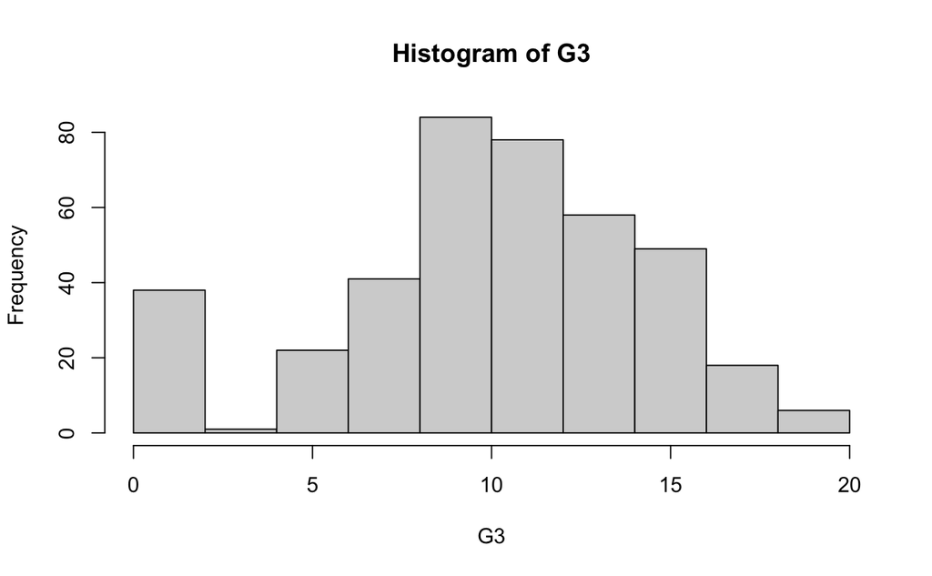

```r
hist(student$G3, main = "Histogram of G3", xlab = "G3", ylab = "Frequency")
```

This histogram is a little bell-shaped.

13. (0.5 pt) Split the data into train and test. Use 80% of samples for training and 20% of samples for testing

```r
n <- nrow(student)
n
```

```
[1] 395
```

```r
train_indices <- sample(1:n, 0.8 * n)  # 80% for training

# Split the data into training and testing sets
train_student_set <- student[train_indices, ]
test_student_set <- student[-train_indices, ]
```

14. set the random seed: set.seed(123)

```r
set.seed(123)
```

5. (2 pt) Use caret package to run 10 fold cross validation using linear regression method on the train data to predict the “G3” variable . Print the resulting model to see the cross validation RMSE. In addition, take a summary of the model and interpret the coefficients. Which coefficients are statistically different from zero? What does this mean? Set the random seed again. We need to do this before each training to ensure we get the same folds in cross validation. Set.seed(123) so we can compare the models using their cross validation RMSE.(2 pts) Use caret and leap packages to run a 10 fold cross validation using step wise linear regression method with backward selection on the train data. The train method by default uses maximum of 4 predictors and reports the best models with 1..4 predictors. We need to change this parameter to consider all predictors. So inside your train function, add the following parameter tuneGrid = data.frame(nvmax = 1:n), where n is the number of variables you use to predict “G3”. Which model (with how many variables or nvmax ) has the lowest cross validation RMSE? Take the summary of the final model, which variables are selected in the model with the lowest RMSE

```r
install.packages("leaps")
```

```r
library(caret)
library(leaps)
set.seed(123)
train_student_set_control <- trainControl(method = "cv", number = 10)
linear_model <- train(G3 ~ ., data = train_student_set, method = "lm", trControl = train_student_set_control)
print(linear_model)
```

```
Linear Regression

316 samples
 32 predictor

No pre-processing
Resampling: Cross-Validated (10 fold)
Summary of sample sizes: 284, 284, 285, 285, 285, 284, ...
Resampling results:

  RMSE      Rsquared   MAE
  2.077776  0.8071742  1.414825

Tuning parameter 'intercept' was held constant at a value of TRUE
```

```r
summary(linear_model$finalModel)
```

```
Call:
lm(formula = .outcome ~ ., data = dat)

Residuals:
    Min      1Q  Median      3Q     Max
-7.8450 -0.5780  0.2497  0.9915  5.0546

Coefficients:
                  Estimate Std. Error t value Pr(>|t|)
(Intercept)      -0.621170   2.384594  -0.260  0.79468
schoolMS          0.299807   0.420397   0.713  0.47636
sexM              0.233282   0.267249   0.873  0.38348
age              -0.105475   0.116404  -0.906  0.36567
addressU          0.090749   0.306521   0.296  0.76741
famsizeLE3       -0.012438   0.257783  -0.048  0.96155
PstatusT         -0.521374   0.423850  -1.230  0.21972
Medu              0.207637   0.170276   1.219  0.22374
Fedu             -0.102152   0.147900  -0.691  0.49035
Mjobhealth       -0.531700   0.597480  -0.890  0.37430
Mjobother        -0.104798   0.383814  -0.273  0.78503
Mjobservices     -0.115455   0.424268  -0.272  0.78573
Mjobteacher      -0.003281   0.551245  -0.006  0.99526
Fjobhealth        0.110021   0.749400   0.147  0.88339
Fjobother        -0.222317   0.557315  -0.399  0.69027
Fjobservices     -0.591327   0.569642  -1.038  0.30015
Fjobteacher      -0.279321   0.701173  -0.398  0.69067
reasonhome       -0.091867   0.300277  -0.306  0.75988
reasonother       0.223044   0.420161   0.531  0.59595
reasonreputation  0.062830   0.306133   0.205  0.83754
guardianmother   -0.069440   0.282916  -0.245  0.80630
guardianother    -0.685895   0.564007  -1.216  0.22499
traveltime       -0.083297   0.184331  -0.452  0.65171
studytime        -0.194241   0.159459  -1.218  0.22422
failures         -0.077735   0.189049  -0.411  0.68126
schoolsupyes      0.407612   0.360203   1.132  0.25878
famsupyes         0.290352   0.255319   1.137  0.25644
paidyes          -0.052417   0.254140  -0.206  0.83675
activitiesyes    -0.211779   0.235462  -0.899  0.36922
nurseryyes       -0.289177   0.294075  -0.983  0.32630
higheryes        -0.071294   0.598042  -0.119  0.90519
internetyes      -0.109438   0.326274  -0.335  0.73757
romanticyes      -0.240888   0.248140  -0.971  0.33252
famrel            0.285458   0.126378   2.259  0.02468 *
freetime          0.060575   0.123973   0.489  0.62550
goout            -0.057330   0.121035  -0.474  0.63612
Dalc             -0.229689   0.176854  -1.299  0.19512
Walc              0.185930   0.133404   1.394  0.16452
health            0.062402   0.084606   0.738  0.46141
absences          0.046943   0.016648   2.820  0.00516 **
G1                0.192133   0.069480   2.765  0.00607 **
G2                0.966345   0.060296  16.027  < 2e-16 ***
---
Signif. codes:  0 ‘***’ 0.001 ‘**’ 0.01 ‘*’ 0.05 ‘.’ 0.1 ‘ ’ 1

Residual standard error: 1.91 on 274 degrees of freedom
Multiple R-squared:  0.8415,    Adjusted R-squared:  0.8178
F-statistic: 35.48 on 41 and 274 DF,  p-value: < 2.2e-16
```

```r
stepwise_model <- train(G3 ~ ., data = train_student_set, method = "leapBackward", tuneGrid = data.frame(nvmax = ncol(train_student_set)-1), trControl=train_student_set_control)
print(stepwise_model)
```

```
Linear Regression with Backwards Selection

316 samples
 32 predictor

No pre-processing
Resampling: Cross-Validated (10 fold)
Summary of sample sizes: 284, 284, 285, 284, 284, 285, ...
Resampling results:

  RMSE      Rsquared   MAE
  1.955166  0.8152011  1.349806

Tuning parameter 'nvmax' was held constant at a value of 32
```

```r
summary(stepwise_model$finalModel)
```

```
Subset selection object
41 Variables  (and intercept)
                 Forced in Forced out
schoolMS             FALSE      FALSE
sexM                 FALSE      FALSE
age                  FALSE      FALSE
addressU             FALSE      FALSE
famsizeLE3           FALSE      FALSE
PstatusT             FALSE      FALSE
Medu                 FALSE      FALSE
Fedu                 FALSE      FALSE
Mjobhealth           FALSE      FALSE
Mjobother            FALSE      FALSE
Mjobservices         FALSE      FALSE
Mjobteacher          FALSE      FALSE
Fjobhealth           FALSE      FALSE
Fjobother            FALSE      FALSE
Fjobservices         FALSE      FALSE
Fjobteacher          FALSE      FALSE
reasonhome           FALSE      FALSE
reasonother          FALSE      FALSE
reasonreputation     FALSE      FALSE
guardianmother       FALSE      FALSE
guardianother        FALSE      FALSE
traveltime           FALSE      FALSE
studytime            FALSE      FALSE
failures             FALSE      FALSE
schoolsupyes         FALSE      FALSE
famsupyes            FALSE      FALSE
paidyes              FALSE      FALSE
activitiesyes        FALSE      FALSE
nurseryyes           FALSE      FALSE
higheryes            FALSE      FALSE
internetyes          FALSE      FALSE
romanticyes          FALSE      FALSE
famrel               FALSE      FALSE
freetime             FALSE      FALSE
goout                FALSE      FALSE
Dalc                 FALSE      FALSE
Walc                 FALSE      FALSE
```

[output cut: 92 more lines]

```
11  ( 1 ) " "    "*"      "*" "*"
12  ( 1 ) " "    "*"      "*" "*"
13  ( 1 ) " "    "*"      "*" "*"
14  ( 1 ) " "    "*"      "*" "*"
15  ( 1 ) " "    "*"      "*" "*"
16  ( 1 ) " "    "*"      "*" "*"
17  ( 1 ) " "    "*"      "*" "*"
18  ( 1 ) " "    "*"      "*" "*"
19  ( 1 ) " "    "*"      "*" "*"
20  ( 1 ) " "    "*"      "*" "*"
21  ( 1 ) " "    "*"      "*" "*"
22  ( 1 ) " "    "*"      "*" "*"
23  ( 1 ) "*"    "*"      "*" "*"
24  ( 1 ) "*"    "*"      "*" "*"
 [ reached getOption("max.print") -- omitted 8 rows ]
```

16. (2pt) Which model does better at predicting G3 based on the cross validation RMSE? Get the predictions of this model for the test data and report RMSE.

```r
linear_rmse <- linear_model$results$RMSE

# Get cross-validation RMSE for stepwise linear regression model
stepwise_rmse <- stepwise_model$results$RMSE

print(linear_rmse)
```

```
[1] 2.077776
```

```r
print(stepwise_rmse)
```

```
[1] 1.955166
```

According to this data,we’ll choose the second type of model because the RMSE is the lowest The model is- Linear Regression with Backwards Selection

```r
test_predictions <- predict(stepwise_model, newdata = test_student_set)
print(test_predictions)
```

```
         3          6         13         29         30         31         38         40         48         51         57         58
 7.5947424 16.6499896 14.3142518 11.9009394 11.7098145 10.6837691 16.1399098 13.9427320 18.7891052 12.4087386 15.2324606 15.7345470
        62         84         92         95         97        105        107        111        116        120        126        138
 7.6401545 15.3336707 17.7984327 12.7664159 15.2727725 19.0355333  7.5516929 21.0318629 16.0165094 13.5723528 13.0912677 -1.4832742
       149        151        152        154        163        165        171        180        189        191        195        201
 4.9165775  2.9876668 13.1236106 -1.1228092 -0.7177211  6.0254408  3.9323169  9.6829481  6.5658876 11.1373850 13.9074398 16.4861144
       204        205        209        211        220        221        227        232        238        245        247        258
 6.2654027  9.0818495  9.2035521  6.2667944  9.1898205  4.1671376 16.2839267 10.5191030 12.6902879 -1.8445857 11.9475203 12.1253904
       259        262        268        277        280        281        290        298        299        305        306        307
14.4349212  7.8243003  9.3929417 11.6287964 10.3120422  9.3260666 14.4185885  6.9646702 12.7219269 13.8411548 11.4734280 18.6370065
       310        316        318        322        342        343        344        347        350        351        353        354
10.3643415 10.7725828  9.0704104  8.8935733  8.7229592 15.5076534  7.5571477 15.5109561 12.9967297  4.8192011  5.7832645  6.4389521
       356        359        367        376        386        388        391
 8.4047014  9.0977737 12.4733499  6.4831124  8.9491420  3.9836690  8.7539793
```

```r
test_rmse <- RMSE(test_predictions, test_student_set$G3)
print(test_rmse)
```

```
[1] 2.01134
```